# Catchment Hydro Lab4

The intro to this lab will be given verbally at the beginning of lab. Please describe how you accomplished each of the tasks below, as well as including your code and plots.

Tips: 1. Use complete sentences. 2. Make sure your answers are clear. 3. Units! 4. Be sure plots have appropiate axis labels.

### Questions:

#### Read the tuck discharge file and plot it one with a linear y axis and once with a log y axis. The code below does this for you.

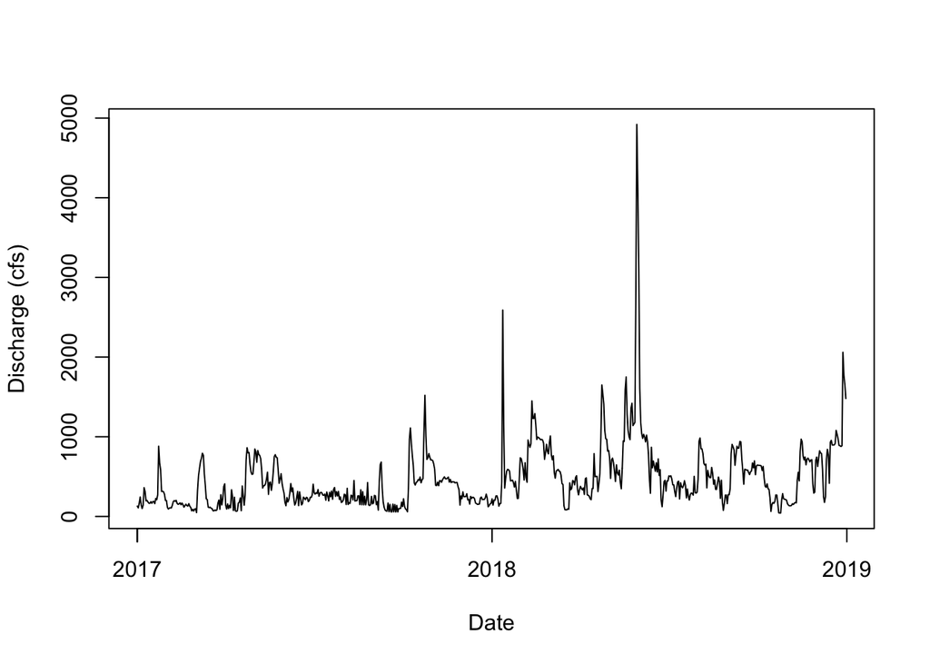

```r
#read csv file
tuck <- read.csv("tuck discharge.csv")

#tell R how to read the dates
#look at the date format by clicking the data in rstudio or
#enter >tuck$datetime[1]
tuck$date <- strptime(tuck$datetime, format = "%m/%d/%y")
tuck$date <- as.POSIXct(tuck$date)

#plot Q v. time
#type makes the plot a line instead of points
#xlab and ylab are the x and y axes
plot(tuck$date, tuck$Q.cfs, type = 'l', ylab = "Discharge (cfs)", xlab = "Date")
```

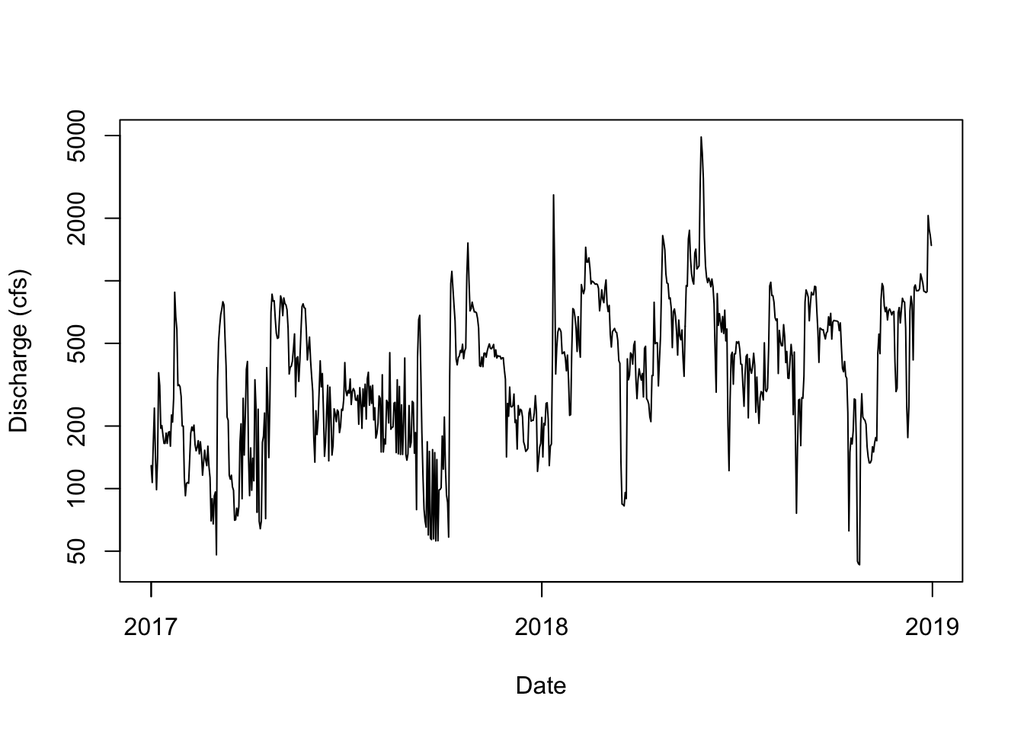

```r
#log y axis to see low flow variations better
#log tells r wwhat axis to log
plot(tuck$date, tuck$Q.cfs, type = 'l',ylab = "Discharge (cfs)", xlab = "Date", log = 'y')
```